# Biostat 212a Homework 4

Due Mar. 5, 2024 @ 11:59PM

Author

Chengwu Duan and 606332825

Published

March 5, 2024

## 1 ISL Exercise 8.4.3 (10pts)

Consider the Gini index, classification error, and entropy in a simple classification setting with two classes. Create a single plot that displays each of these quantities as a function of $\hat{p}_{m1}$. The x-axis should display $\hat{p}_{m1}$, ranging from 0 to 1, and the y-axis should display the value of the Gini index, classification error, and entropy.

Hint: In a setting with two classes, $\hat{p}_{m1}$ = 1− $\hat{p}_{m2}$. You could make this plot by hand, but it will be much easier to make in R.

**Answer:**

$\hat{p}_{mk}$ is the proportion of training observations in the $m^{th}$ region that are from the $k^{th}$ class.

The Gini index is defined by

$$\begin{align}
G &= \sum_{k=1}^{K} \hat{p}_{mk} (1 - \hat{p}_{mk})\\
&= \hat{p}_{m1} (1 - \hat{p}_{m1}) + \hat{p}_{m2} (1 - \hat{p}_{m2})\\
\end{align}$$
Classification error is defined by

$$\begin{align}
E &= 1 - \max_k \hat{p}_{mk}\\
&= 1 - \max(\hat{p}_{m1}, \hat{p}_{m2})
\end{align}$$
Entropy is defined by

$$\begin{align}
D &= -\sum_{k=1}^{K} \hat{p}_{mk} \log \hat{p}_{mk}\\
&= -\hat{p}_{m1} \log \hat{p}_{m1} - \hat{p}_{m2} \log \hat{p}_{m2}
\end{align}$$

```r
library(memuse)
# check how much RAM
memuse::Sys.meminfo()
```

```
Totalram:  7.667 GiB
Freeram:   4.360 GiB
```

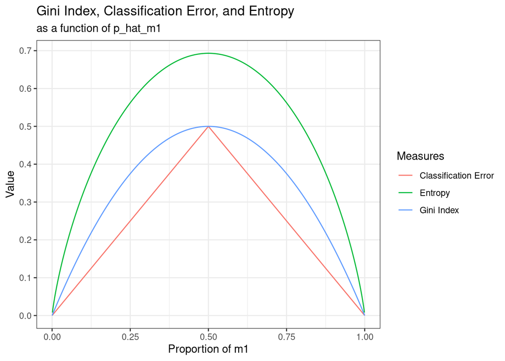

```r
library(tidyverse)
library(ggplot2)

phat.m1 <- seq(0, 1, 0.001)
phat.m2 <- 1 - phat.m1

gini_index <- phat.m1*(1-phat.m1) + phat.m2*(1-phat.m2)
class_error <- 1 - pmax(phat.m1, phat.m2)
entropy <- -phat.m1*log(phat.m1) - phat.m2*log(phat.m2)


data.frame(phat.m1, phat.m2, class_error, gini_index, entropy) %>%
  pivot_longer(cols = c(class_error, gini_index, entropy), names_to = "measures") %>%
    ggplot(aes(x = phat.m1, y = value, col = factor(measures))) +
    geom_line() +
    scale_y_continuous(breaks = seq(0, 1, 0.1), minor_breaks = NULL) +
    scale_color_hue(labels = c("Classification Error", "Entropy", "Gini Index")) +
    labs(title = "Gini Index, Classification Error, and Entropy",
         subtitle = "as a function of p_hat_m1",
         col = "Measures",
         y = "Value",
         x = "Proportion of m1") +
  theme_bw()
```

## 2 ISL Exercise 8.4.4 (10pts)

This question relates to the plots in Figure 8.14.

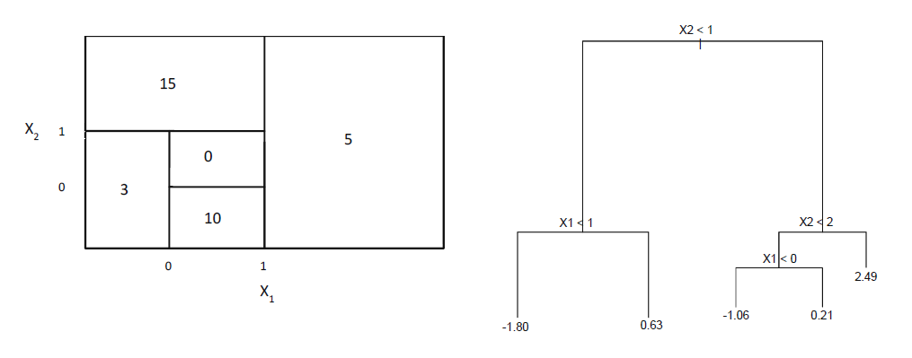

1. Sketch the tree corresponding to the partition of the predictor space illustrated in the left-hand panel of Figure 8.14. The numbers inside the boxes indicate the mean of Y within each region.

**Answer:**

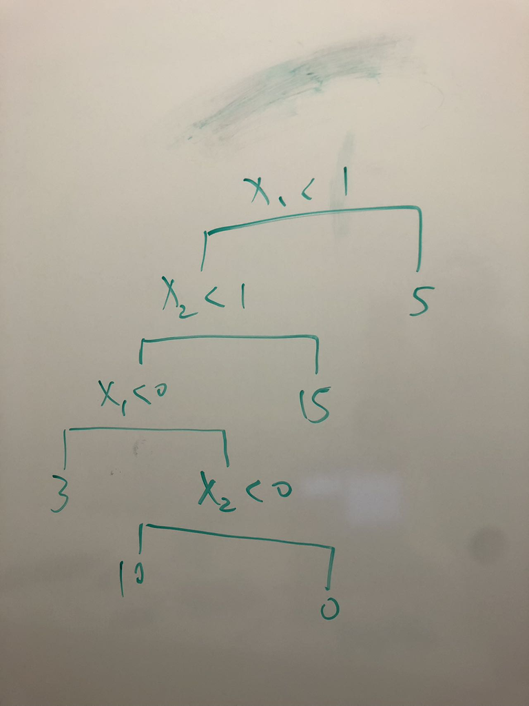

2. Create a diagram similar to the left-hand panel of Figure 8.14, using the tree illustrated in the right-hand panel of the same figure. You should divide up the predictor space into the correct regions, and indicate the mean for each region.

**Answer:**

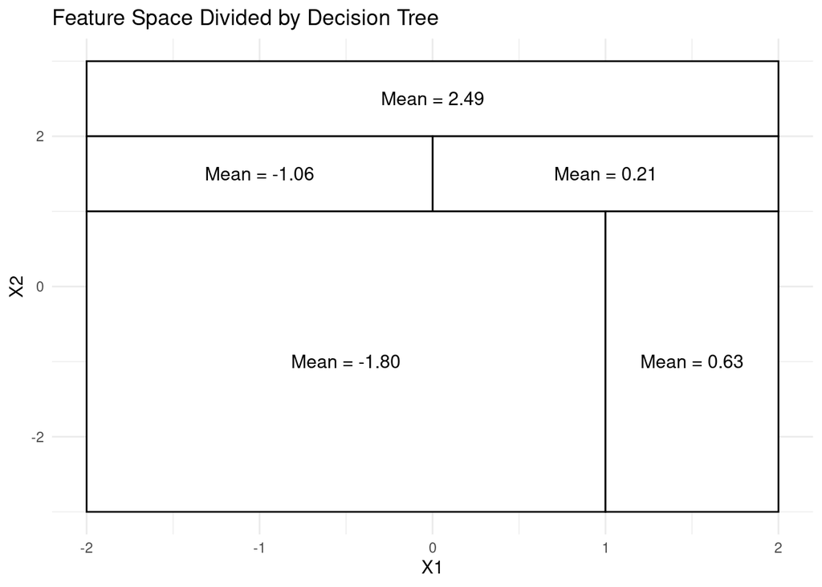

```r
library(ggplot2)

# Create an empty plot
ggplot() +
  # set the x and y limits
  xlim(c(-2, 2)) +
  ylim(c(-3, 3)) +
  # Add rectangles for the regions
  geom_rect(aes(xmin=-2, xmax=2, ymin=2, ymax=3), fill="white", color="black") +
  geom_rect(aes(xmin=0, xmax=2, ymin=1, ymax=2), fill="white", color="black") +
  geom_rect(aes(xmin=-2, xmax=0, ymin=1, ymax=2), fill="white", color="black") +
  geom_rect(aes(xmin=-2, xmax=1, ymin=-3, ymax=1), fill="white", color="black") +
  geom_rect(aes(xmin=1, xmax=2, ymin=-3, ymax=1), fill="white", color="black") +
  # Annotate the regions with the corresponding mean values
  annotate("text", x = 0, y = 2.5, label = "Mean = 2.49", size=4) +
  annotate("text", x = -1, y = 1.5, label = "Mean = -1.06", size=4) +
  annotate("text", x = 1, y = 1.5, label = "Mean = 0.21", size=4) +
  annotate("text", x = -0.5, y = -1, label = "Mean = -1.80", size=4) +
  annotate("text", x = 1.5, y = -1, label = "Mean = 0.63", size=4) +
  # Add labels and theme adjustments
  labs(x="X1", y="X2", title="Feature Space Divided by Decision Tree") +
  theme_minimal()
```

## 3 ISL Exercise 8.4.5 (10pts)

Suppose we produce ten bootstrapped samples from a data set containing red and green classes. We then apply a classification tree to each bootstrapped sample and, for a specific value of X, produce 10 estimates of P(Class is Red|X):

0.1, 0.15, 0.2, 0.2, 0.55, 0.6, 0.6, 0.65, 0.7, and 0.75.

There are two common ways to combine these results together into a single class prediction. One is the majority vote approach discussed in this chapter. The second approach is to classify based on the average probability. In this example, what is the final classification under each of these two approaches?

**Answer:**

```r
probs <- c(0.1, 0.15, 0.2, 0.2, 0.55, 0.6, 0.6, 0.65, 0.7, 0.75)

# Majority vote approach
(Majority_vote_approach <- ifelse(sum(probs > 0.5) > 5, "red", "green"))
```

```
[1] "red"
```

```r
# Average approach
(Average_approach <- ifelse(mean(probs) > 0.5, "red", "green"))
```

```
[1] "green"
```

The majority vote approach would classify the observation as red, since 6 out of the 10 trees predict a probability of red more than 0.5. The average probability approach would classify the observation as green, since the average of the 10 probabilities is 0.45.

## 4 ISL Lab 8.3. `Boston` data set (30pts)

Follow the machine learning workflow to train regression tree, random forest, and boosting methods for predicting `medv`. Evaluate out-of-sample performance on a test set.

**Answer:**

### 4.1 RF for prediction

```r
library(GGally)
library(gtsummary)
library(ranger)
library(tidyverse)
library(tidymodels)
library(ISLR2)
library(workflows)

# Numerical summaries stratified by the outcome `AHD`.
Boston %>% tbl_summary()
```

| **Characteristic** | **N = 506**<sup>1</sup> |
| --- | --- |
| crim | 0.3 (0.1, 3.7) |
| zn | 0 (0, 13) |
| indus | 9.7 (5.2, 18.1) |
| chas | 35 (6.9%) |
| nox | 0.54 (0.45, 0.62) |
| rm | 6.21 (5.89, 6.62) |
| age | 78 (45, 94) |
| dis | 3.21 (2.10, 5.19) |
| rad |  |
| 1 | 20 (4.0%) |
| 2 | 24 (4.7%) |
| 3 | 38 (7.5%) |
| 4 | 110 (22%) |
| 5 | 115 (23%) |
| 6 | 26 (5.1%) |
| 7 | 17 (3.4%) |
| 8 | 24 (4.7%) |
| 24 | 132 (26%) |
| tax | 330 (279, 666) |
| ptratio | 19.05 (17.40, 20.20) |
| lstat | 11 (7, 17) |
| medv | 21 (17, 25) |

<sup>1</sup> Median (IQR); n (%)

```r
# reproducibility
set.seed(123)

# Split the data into training and testing sets
data_split <- initial_split(
  Boston,
  prop = 0.5
  )
data_split
```

```
<Training/Testing/Total>
<253/253/506>
```

```r
boston_train <- training(data_split)
dim(boston_train)
```

```
[1] 253  13
```

```r
boston_test <- testing(data_split)
dim(boston_test)
```

```
[1] 253  13
```

```r
rf_recipe <-
  recipe(
    medv ~ .,
    data = boston_train
  ) %>%
  # create traditional dummy variables (not necessary for random forest in R)
  # omit all NAs in medv
  step_naomit(medv) %>%
  # zero-variance filter
  step_zv(all_numeric_predictors())
  # center and scale numeric data (not necessary for random forest)
  # estimate the means and standard deviations
  # prep(training = boston_train, retain = TRUE)

rf_recipe

rf_model <-
  rand_forest(
    mode = "regression",
    # number of predictors randomly sampled in each split
    mtry = tune(),
    # number of trees in ensemble
    trees = tune()
  ) %>%
  set_engine("ranger")

rf_model
```

```
Random Forest Model Specification (regression)

Main Arguments:
  mtry = tune()
  trees = tune()

Computational engine: ranger
```

```r
rf_workflow <-
  workflow() %>%
  add_recipe(rf_recipe) %>%
  add_model(rf_model)

rf_workflow
```

```
══ Workflow ════════════════════════════════════════════════════════════════════
Preprocessor: Recipe
Model: rand_forest()

── Preprocessor ────────────────────────────────────────────────────────────────
2 Recipe Steps

• step_naomit()
• step_zv()

── Model ───────────────────────────────────────────────────────────────────────
Random Forest Model Specification (regression)

Main Arguments:
  mtry = tune()
  trees = tune()

Computational engine: ranger
```

```r
rf_grid <- grid_regular(
  trees(range = c(100L, 1500L)),
  mtry(range = c(1L, 4L)),
  levels = c(15,4)
  )
rf_grid
```

```
# A tibble: 60 × 2
   trees  mtry
   <int> <int>
 1   100     1
 2   200     1
 3   300     1
 4   400     1
 5   500     1
 6   600     1
 7   700     1
 8   800     1
 9   900     1
10  1000     1
# ℹ 50 more rows
```

```r
set.seed(203)

folds <- vfold_cv(boston_train, v = 5)
folds
```

```
#  5-fold cross-validation
# A tibble: 5 × 2
  splits           id
  <list>           <chr>
1 <split [202/51]> Fold1
2 <split [202/51]> Fold2
3 <split [202/51]> Fold3
4 <split [203/50]> Fold4
5 <split [203/50]> Fold5
```

```r
rf_fit <- rf_workflow %>%
  tune_grid(
    resamples = folds,
    grid = rf_grid,
    metrics = metric_set(rmse, rsq)
    )
rf_fit
```

```
# Tuning results
# 5-fold cross-validation
# A tibble: 5 × 4
  splits           id    .metrics           .notes
  <list>           <chr> <list>             <list>
1 <split [202/51]> Fold1 <tibble [120 × 6]> <tibble [0 × 3]>
2 <split [202/51]> Fold2 <tibble [120 × 6]> <tibble [0 × 3]>
3 <split [202/51]> Fold3 <tibble [120 × 6]> <tibble [0 × 3]>
4 <split [203/50]> Fold4 <tibble [120 × 6]> <tibble [0 × 3]>
5 <split [203/50]> Fold5 <tibble [120 × 6]> <tibble [0 × 3]>
```

```
# A tibble: 120 × 8
    mtry trees .metric .estimator  mean     n std_err .config
   <int> <int> <chr>   <chr>      <dbl> <int>   <dbl> <chr>
 1     1   100 rmse    standard   4.98      5  0.313  Preprocessor1_Model01
 2     1   100 rsq     standard   0.727     5  0.0534 Preprocessor1_Model01
 3     1   200 rmse    standard   4.96      5  0.262  Preprocessor1_Model02
 4     1   200 rsq     standard   0.740     5  0.0462 Preprocessor1_Model02
 5     1   300 rmse    standard   5.07      5  0.308  Preprocessor1_Model03
 6     1   300 rsq     standard   0.723     5  0.0488 Preprocessor1_Model03
 7     1   400 rmse    standard   4.98      5  0.321  Preprocessor1_Model04
 8     1   400 rsq     standard   0.734     5  0.0455 Preprocessor1_Model04
 9     1   500 rmse    standard   5.00      5  0.300  Preprocessor1_Model05
10     1   500 rsq     standard   0.731     5  0.0487 Preprocessor1_Model05
# ℹ 110 more rows
```

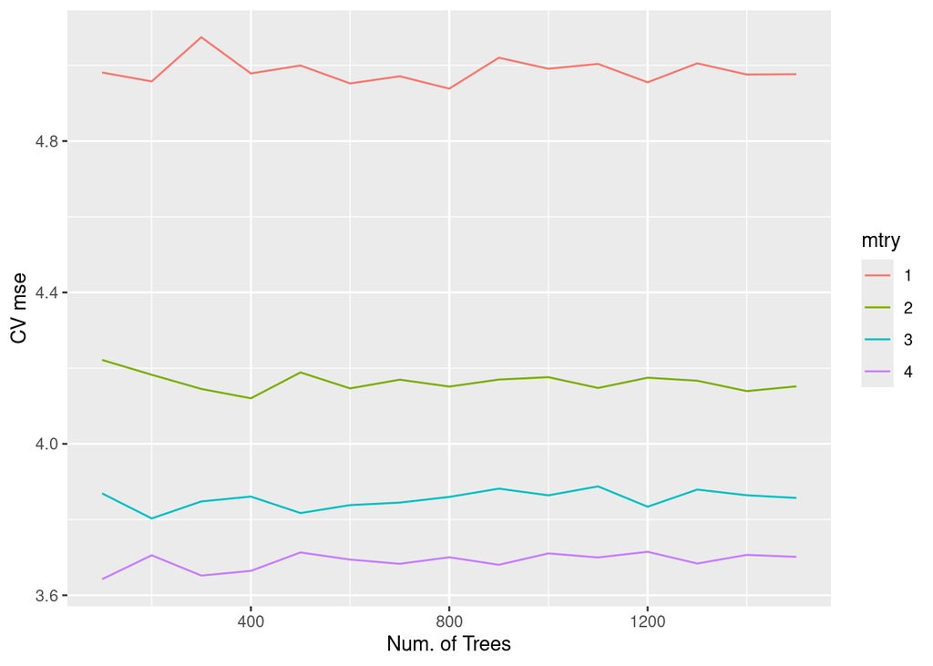

```r
rf_fit %>%
  collect_metrics() %>%
  print(width = Inf) %>%
  filter(.metric == "rmse") %>%
  mutate(mtry = as.factor(mtry)) %>%
  ggplot(mapping = aes(x = trees, y = mean, color = mtry)) +
  # geom_point() +
  geom_line() +
  labs(x = "Num. of Trees", y = "CV mse")
```

```r
rf_fit %>%
  show_best("rmse")
```

```
# A tibble: 5 × 8
   mtry trees .metric .estimator  mean     n std_err .config
  <int> <int> <chr>   <chr>      <dbl> <int>   <dbl> <chr>
1     4   100 rmse    standard    3.64     5   0.403 Preprocessor1_Model46
2     4   300 rmse    standard    3.65     5   0.420 Preprocessor1_Model48
3     4   400 rmse    standard    3.66     5   0.405 Preprocessor1_Model49
4     4   900 rmse    standard    3.68     5   0.389 Preprocessor1_Model54
5     4   700 rmse    standard    3.68     5   0.407 Preprocessor1_Model52
```

```r
best_rf <- rf_fit %>%
  select_best("rmse")
best_rf
```

```
# A tibble: 1 × 3
   mtry trees .config
  <int> <int> <chr>
1     4   100 Preprocessor1_Model46
```

```r
# Final workflow
final_wf <- rf_workflow %>%
  finalize_workflow(best_rf)
final_wf
```

```
══ Workflow ════════════════════════════════════════════════════════════════════
Preprocessor: Recipe
Model: rand_forest()

── Preprocessor ────────────────────────────────────────────────────────────────
2 Recipe Steps

• step_naomit()
• step_zv()

── Model ───────────────────────────────────────────────────────────────────────
Random Forest Model Specification (regression)

Main Arguments:
  mtry = 4
  trees = 100

Computational engine: ranger
```

```r
# Fit the whole training set, then predict the test cases
final_fit <-
  final_wf %>%
  last_fit(data_split)
final_fit
```

```
# Resampling results
# Manual resampling
# A tibble: 1 × 6
  splits            id               .metrics .notes   .predictions .workflow
  <list>            <chr>            <list>   <list>   <list>       <list>
1 <split [253/253]> train/test split <tibble> <tibble> <tibble>     <workflow>
```

```r
# Test metrics
final_fit %>%
  collect_metrics()
```

```
# A tibble: 2 × 4
  .metric .estimator .estimate .config
  <chr>   <chr>          <dbl> <chr>
1 rmse    standard       3.58  Preprocessor1_Model1
2 rsq     standard       0.857 Preprocessor1_Model1
```

**Answer:** The best training rmse is about 3.64 while the test rmse is about 3.58, inferring that the model was not overfitting. There is a slight improvement in the prediction accruacy of the test set. The test error magnitude of 3.58 suggests that the model prediction will deviate from the true median value by about $3,580 on average in the context of `medv`. If home values are generally high this deviation of 3500 dollars may be acceptable but with low value homes this can contribute to a significant error. For a general purpose prediction, this approach can be acceptable, but a test rmse is not exactly low.

### 4.2 Boosting for prediction

```r
library(GGally)
library(gtsummary)
library(ranger)
library(tidyverse)
library(tidymodels)
library(ISLR2)

# Numerical summaries stratified by the outcome `AHD`.
Boston %>% tbl_summary()
```

| **Characteristic** | **N = 506**<sup>1</sup> |
| --- | --- |
| crim | 0.3 (0.1, 3.7) |
| zn | 0 (0, 13) |
| indus | 9.7 (5.2, 18.1) |
| chas | 35 (6.9%) |
| nox | 0.54 (0.45, 0.62) |
| rm | 6.21 (5.89, 6.62) |
| age | 78 (45, 94) |
| dis | 3.21 (2.10, 5.19) |
| rad |  |
| 1 | 20 (4.0%) |
| 2 | 24 (4.7%) |
| 3 | 38 (7.5%) |
| 4 | 110 (22%) |
| 5 | 115 (23%) |
| 6 | 26 (5.1%) |
| 7 | 17 (3.4%) |
| 8 | 24 (4.7%) |
| 24 | 132 (26%) |
| tax | 330 (279, 666) |
| ptratio | 19.05 (17.40, 20.20) |
| lstat | 11 (7, 17) |
| medv | 21 (17, 25) |

<sup>1</sup> Median (IQR); n (%)

```r
# Split the data into training and testing sets
data_split <- initial_split(
  Boston,
  prop = 0.5
  )
data_split
```

```
<Training/Testing/Total>
<253/253/506>
```

```r
boston_train <- training(data_split)
dim(boston_train)
```

```
[1] 253  13
```

```r
boston_test <- testing(data_split)
dim(boston_test)
```

```
[1] 253  13
```

```r
gb_recipe <-
  recipe(
    medv ~ .,
    data = boston_train
  ) %>%
  # # create traditional dummy variables (not necessary for random forest in R)
  # step_dummy(all_nominal()) %>%
  step_naomit(medv) %>%
  # zero-variance filter
  step_zv(all_numeric_predictors())
  # # center and scale numeric data (not necessary for random forest)
  # step_normalize(all_numeric_predictors()) %>%
  # estimate the means and standard deviations
  # prep(training = boston_train, retain = TRUE)
gb_recipe

gb_mod <-
  boost_tree(
    mode = "regression",
    trees = 1000,
    tree_depth = tune(),
    learn_rate = tune()
  ) %>%
  set_engine("xgboost")
gb_mod
```

```
Boosted Tree Model Specification (regression)

Main Arguments:
  trees = 1000
  tree_depth = tune()
  learn_rate = tune()

Computational engine: xgboost
```

```r
gb_wf <- workflow() %>%
  add_recipe(gb_recipe) %>%
  add_model(gb_mod)
gb_wf
```

```
══ Workflow ════════════════════════════════════════════════════════════════════
Preprocessor: Recipe
Model: boost_tree()

── Preprocessor ────────────────────────────────────────────────────────────────
2 Recipe Steps

• step_naomit()
• step_zv()

── Model ───────────────────────────────────────────────────────────────────────
Boosted Tree Model Specification (regression)

Main Arguments:
  trees = 1000
  tree_depth = tune()
  learn_rate = tune()

Computational engine: xgboost
```

```r
param_grid <- grid_regular(
  tree_depth(range = c(1L, 4L)),
  learn_rate(range = c(-10, -0.5), trans = log10_trans()),
  levels = c(4, 10)
  )
param_grid
```

```
# A tibble: 40 × 2
   tree_depth    learn_rate
        <int>         <dbl>
 1          1 0.0000000001
 2          2 0.0000000001
 3          3 0.0000000001
 4          4 0.0000000001
 5          1 0.00000000114
 6          2 0.00000000114
 7          3 0.00000000114
 8          4 0.00000000114
 9          1 0.0000000129
10          2 0.0000000129
# ℹ 30 more rows
```

```r
set.seed(203)

folds <- vfold_cv(boston_train, v = 5)
folds
```

```
#  5-fold cross-validation
# A tibble: 5 × 2
  splits           id
  <list>           <chr>
1 <split [202/51]> Fold1
2 <split [202/51]> Fold2
3 <split [202/51]> Fold3
4 <split [203/50]> Fold4
5 <split [203/50]> Fold5
```

```r
gb_fit <- gb_wf %>%
  tune_grid(
    resamples = folds,
    grid = param_grid,
    metrics = metric_set(rmse, rsq)
    )
gb_fit
```

```
# Tuning results
# 5-fold cross-validation
# A tibble: 5 × 4
  splits           id    .metrics          .notes
  <list>           <chr> <list>            <list>
1 <split [202/51]> Fold1 <tibble [80 × 6]> <tibble [1 × 3]>
2 <split [202/51]> Fold2 <tibble [0 × 6]>  <NULL>
3 <split [202/51]> Fold3 <tibble [0 × 6]>  <NULL>
4 <split [203/50]> Fold4 <tibble [0 × 6]>  <NULL>
5 <split [203/50]> Fold5 <tibble [0 × 6]>  <NULL>

There were issues with some computations:

  - Warning(s) x1: A correlation computation is required, but `estimate` is constant...

Run `show_notes(.Last.tune.result)` for more information.
```

```
# A tibble: 80 × 8
   tree_depth    learn_rate .metric .estimator    mean     n std_err
        <int>         <dbl> <chr>   <chr>        <dbl> <int>   <dbl>
 1          1 0.0000000001  rmse    standard    22.9       1      NA
 2          1 0.0000000001  rsq     standard   NaN         0      NA
 3          2 0.0000000001  rmse    standard    22.9       1      NA
 4          2 0.0000000001  rsq     standard   NaN         0      NA
 5          3 0.0000000001  rmse    standard    22.9       1      NA
 6          3 0.0000000001  rsq     standard   NaN         0      NA
 7          4 0.0000000001  rmse    standard    22.9       1      NA
 8          4 0.0000000001  rsq     standard   NaN         0      NA
 9          1 0.00000000114 rmse    standard    22.9       1      NA
10          1 0.00000000114 rsq     standard     0.386     1      NA
   .config
   <chr>
 1 Preprocessor1_Model01
 2 Preprocessor1_Model01
 3 Preprocessor1_Model02
 4 Preprocessor1_Model02
 5 Preprocessor1_Model03
 6 Preprocessor1_Model03
 7 Preprocessor1_Model04
 8 Preprocessor1_Model04
 9 Preprocessor1_Model05
10 Preprocessor1_Model05
# ℹ 70 more rows
```

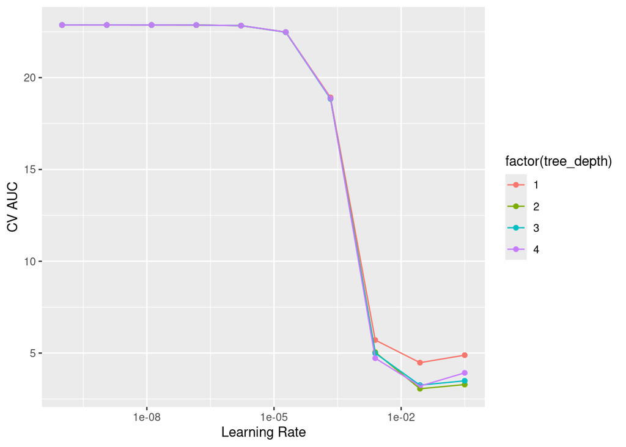

```r
gb_fit %>%
  collect_metrics() %>%
  print(width = Inf) %>%
  filter(.metric == "rmse") %>%
  ggplot(mapping = aes(x = learn_rate, y = mean, color = factor(tree_depth))) +
  geom_point() +
  geom_line() +
  labs(x = "Learning Rate", y = "CV AUC") +
  scale_x_log10()
```

```r
gb_fit %>%
  show_best("rmse")
```

```
# A tibble: 5 × 8
  tree_depth learn_rate .metric .estimator  mean     n std_err .config
       <int>      <dbl> <chr>   <chr>      <dbl> <int>   <dbl> <chr>
1          2     0.0278 rmse    standard    3.06     1      NA Preprocessor1_Mo…
2          4     0.0278 rmse    standard    3.20     1      NA Preprocessor1_Mo…
3          3     0.0278 rmse    standard    3.25     1      NA Preprocessor1_Mo…
4          2     0.316  rmse    standard    3.28     1      NA Preprocessor1_Mo…
5          3     0.316  rmse    standard    3.49     1      NA Preprocessor1_Mo…
```

```r
best_gb <- gb_fit %>%
  select_best("rmse")
best_gb
```

```
# A tibble: 1 × 3
  tree_depth learn_rate .config
       <int>      <dbl> <chr>
1          2     0.0278 Preprocessor1_Model34
```

```r
# Final workflow
final_wf <- gb_wf %>%
  finalize_workflow(best_gb)
final_wf
```

```
══ Workflow ════════════════════════════════════════════════════════════════════
Preprocessor: Recipe
Model: boost_tree()

── Preprocessor ────────────────────────────────────────────────────────────────
2 Recipe Steps

• step_naomit()
• step_zv()

── Model ───────────────────────────────────────────────────────────────────────
Boosted Tree Model Specification (regression)

Main Arguments:
  trees = 1000
  tree_depth = 2
  learn_rate = 0.0278255940220713

Computational engine: xgboost
```

```r
# Fit the whole training set, then predict the test cases
final_fit <-
  final_wf %>%
  last_fit(data_split)
final_fit
```

```
# Resampling results
# Manual resampling
# A tibble: 1 × 6
  splits            id               .metrics .notes   .predictions .workflow
  <list>            <chr>            <list>   <list>   <list>       <list>
1 <split [253/253]> train/test split <tibble> <tibble> <tibble>     <workflow>
```

```r
# Test metrics
final_fit %>%
  collect_metrics()
```

```
# A tibble: 2 × 4
  .metric .estimator .estimate .config
  <chr>   <chr>          <dbl> <chr>
1 rmse    standard       3.49  Preprocessor1_Model1
2 rsq     standard       0.834 Preprocessor1_Model1
```

**Answer:** The best training rmse is about 3.06 while the test rmse is about 3.49. There is a slight downgrade in the prediction accruacy of the test set. The test error magnitude of 3.49 suggests that the model prediction will deviate from the true median value by about $3,490 on average in the context of `medv`. In comparison, boosting tree performed better than random forest with a lower rmse estimate, but the improvement is marginal.

```r
library(vip)

#library(rpart.plot)
final_tree <- extract_workflow(final_fit)
final_tree
```

```
══ Workflow [trained] ══════════════════════════════════════════════════════════
Preprocessor: Recipe
Model: boost_tree()

── Preprocessor ────────────────────────────────────────────────────────────────
2 Recipe Steps

• step_naomit()
• step_zv()

── Model ───────────────────────────────────────────────────────────────────────
##### xgb.Booster
raw: 872.5 Kb
call:
  xgboost::xgb.train(params = list(eta = 0.0278255940220713, max_depth = 2L,
    gamma = 0, colsample_bytree = 1, colsample_bynode = 1, min_child_weight = 1,
    subsample = 1), data = x$data, nrounds = 1000, watchlist = x$watchlist,
    verbose = 0, nthread = 1, objective = "reg:squarederror")
params (as set within xgb.train):
  eta = "0.0278255940220713", max_depth = "2", gamma = "0", colsample_bytree = "1", colsample_bynode = "1", min_child_weight = "1", subsample = "1", nthread = "1", objective = "reg:squarederror", validate_parameters = "TRUE"
xgb.attributes:
  niter
callbacks:
  cb.evaluation.log()
# of features: 12
niter: 1000
nfeatures : 12
evaluation_log:
     iter training_rmse
    <num>         <num>
        1     24.126609
        2     23.499835
---
      999      1.174166
     1000      1.173828
```

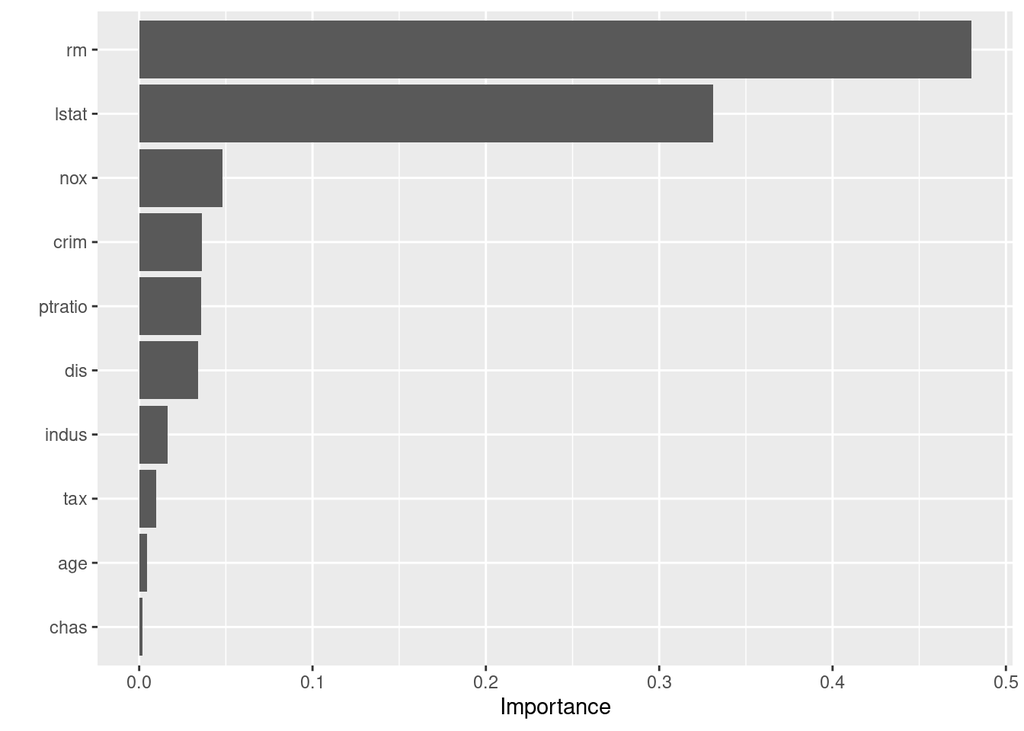

```r
final_tree %>%
  extract_fit_parsnip() %>%
  vip()
```

## 5 ISL Lab 8.3 `Carseats` data set (30pts)

Follow the machine learning workflow to train classification tree, random forest, and boosting methods for classifying `Sales <= 8` versus `Sales > 8`. Evaluate out-of-sample performance on a test set.

**Answer:**

### 5.1 RF for classification

```r
# Load libraries
library(GGally)
library(gtsummary)
library(ranger)
library(tidyverse)
library(tidymodels)
library(ISLR2)

# checking for missing values
summary(Carseats)
```

```
     Sales          CompPrice       Income        Advertising
 Min.   : 0.000   Min.   : 77   Min.   : 21.00   Min.   : 0.000
 1st Qu.: 5.390   1st Qu.:115   1st Qu.: 42.75   1st Qu.: 0.000
 Median : 7.490   Median :125   Median : 69.00   Median : 5.000
 Mean   : 7.496   Mean   :125   Mean   : 68.66   Mean   : 6.635
 3rd Qu.: 9.320   3rd Qu.:135   3rd Qu.: 91.00   3rd Qu.:12.000
 Max.   :16.270   Max.   :175   Max.   :120.00   Max.   :29.000
   Population        Price        ShelveLoc        Age          Education
 Min.   : 10.0   Min.   : 24.0   Bad   : 96   Min.   :25.00   Min.   :10.0
 1st Qu.:139.0   1st Qu.:100.0   Good  : 85   1st Qu.:39.75   1st Qu.:12.0
 Median :272.0   Median :117.0   Medium:219   Median :54.50   Median :14.0
 Mean   :264.8   Mean   :115.8                Mean   :53.32   Mean   :13.9
 3rd Qu.:398.5   3rd Qu.:131.0                3rd Qu.:66.00   3rd Qu.:16.0
 Max.   :509.0   Max.   :191.0                Max.   :80.00   Max.   :18.0
 Urban       US
 No :118   No :142
 Yes:282   Yes:258
```

```r
colSums(is.na(Carseats))
```

```
      Sales   CompPrice      Income Advertising  Population       Price
          0           0           0           0           0           0
  ShelveLoc         Age   Education       Urban          US
          0           0           0           0           0
```

```r
Carseats %>% tbl_summary()
```

| **Characteristic** | **N = 400**<sup>1</sup> |
| --- | --- |
| Sales | 7.49 (5.39, 9.32) |
| CompPrice | 125 (115, 135) |
| Income | 69 (43, 91) |
| Advertising | 5.0 (0.0, 12.0) |
| Population | 272 (139, 399) |
| Price | 117 (100, 131) |
| ShelveLoc |  |
| Bad | 96 (24%) |
| Good | 85 (21%) |
| Medium | 219 (55%) |
| Age | 55 (40, 66) |
| Education |  |
| 10 | 48 (12%) |
| 11 | 48 (12%) |
| 12 | 49 (12%) |
| 13 | 43 (11%) |
| 14 | 40 (10%) |
| 15 | 36 (9.0%) |
| 16 | 47 (12%) |
| 17 | 49 (12%) |
| 18 | 40 (10%) |
| Urban | 282 (71%) |
| US | 258 (65%) |

<sup>1</sup> Median (IQR); n (%)

```r
# For reproducibility
set.seed(203)

# creating an outcome variable
carseats <- Carseats %>%
  mutate(SalesHL = ifelse(Sales <= 8, "Low", "High")) %>%
  select(-Sales)

data_split <- initial_split(
  carseats,
  # stratify by AHD
  strata = "SalesHL",
  prop = 0.75
  )
data_split
```

```
<Training/Testing/Total>
<300/100/400>
```

```r
carseats_train <- training(data_split)
dim(carseats_train)
```

```
[1] 300  11
```

```r
carseats_test <- testing(data_split)
dim(carseats_test)
```

```
[1] 100  11
```

```r
rf_recipe <-
  recipe(
    SalesHL ~ .,
    data = carseats_train
  ) %>%
  # # create traditional dummy variables (not necessary for random forest in R)
  # step_dummy(all_nominal()) %>%

  # no NAs in carseats
  # # mean imputation for Ca
  # step_impute_mean(Ca) %>%
  # # mode imputation for Thal
  # step_impute_mode(Thal) %>%


  # zero-variance filter
  step_zv(all_numeric_predictors())
  # # center and scale numeric data (not necessary for random forest)
  # step_normalize(all_numeric_predictors()) %>%
  # estimate the means and standard deviations
  # prep(training = carseats_train, retain = TRUE)
rf_recipe

rf_mod <-
  rand_forest(
    mode = "classification",
    # Number of predictors randomly sampled in each split
    mtry = tune(),
    # Number of trees in ensemble
    trees = tune()
  ) %>%
  set_engine("ranger")
rf_mod
```

```
Random Forest Model Specification (classification)

Main Arguments:
  mtry = tune()
  trees = tune()

Computational engine: ranger
```

```r
rf_wf <- workflow() %>%
  add_recipe(rf_recipe) %>%
  add_model(rf_mod)
rf_wf
```

```
══ Workflow ════════════════════════════════════════════════════════════════════
Preprocessor: Recipe
Model: rand_forest()

── Preprocessor ────────────────────────────────────────────────────────────────
1 Recipe Step

• step_zv()

── Model ───────────────────────────────────────────────────────────────────────
Random Forest Model Specification (classification)

Main Arguments:
  mtry = tune()
  trees = tune()

Computational engine: ranger
```

```r
param_grid <- grid_regular(
  trees(range = c(1L, 1000L)),
  mtry(range = c(1L, 6L)),
  levels = c(9, 6)
  )
param_grid
```

```
# A tibble: 54 × 2
   trees  mtry
   <int> <int>
 1     1     1
 2   125     1
 3   250     1
 4   375     1
 5   500     1
 6   625     1
 7   750     1
 8   875     1
 9  1000     1
10     1     2
# ℹ 44 more rows
```

```r
set.seed(203)

folds <- vfold_cv(carseats_train, v = 5)
folds
```

```
#  5-fold cross-validation
# A tibble: 5 × 2
  splits           id
  <list>           <chr>
1 <split [240/60]> Fold1
2 <split [240/60]> Fold2
3 <split [240/60]> Fold3
4 <split [240/60]> Fold4
5 <split [240/60]> Fold5
```

```r
rf_fit <- rf_wf %>%
  tune_grid(
    resamples = folds,
    grid = param_grid,
    metrics = metric_set(roc_auc, accuracy)
    )
rf_fit
```

```
# Tuning results
# 5-fold cross-validation
# A tibble: 5 × 4
  splits           id    .metrics           .notes
  <list>           <chr> <list>             <list>
1 <split [240/60]> Fold1 <tibble [108 × 6]> <tibble [0 × 3]>
2 <split [240/60]> Fold2 <tibble [108 × 6]> <tibble [0 × 3]>
3 <split [240/60]> Fold3 <tibble [108 × 6]> <tibble [0 × 3]>
4 <split [240/60]> Fold4 <tibble [108 × 6]> <tibble [0 × 3]>
5 <split [240/60]> Fold5 <tibble [108 × 6]> <tibble [0 × 3]>
```

```
# A tibble: 108 × 8
    mtry trees .metric  .estimator  mean     n std_err .config
   <int> <int> <chr>    <chr>      <dbl> <int>   <dbl> <chr>
 1     1     1 accuracy binary     0.55      5 0.0387  Preprocessor1_Model01
 2     1     1 roc_auc  binary     0.578     5 0.0367  Preprocessor1_Model01
 3     1   125 accuracy binary     0.75      5 0.0175  Preprocessor1_Model02
 4     1   125 roc_auc  binary     0.846     5 0.00895 Preprocessor1_Model02
 5     1   250 accuracy binary     0.767     5 0.0183  Preprocessor1_Model03
 6     1   250 roc_auc  binary     0.837     5 0.00981 Preprocessor1_Model03
 7     1   375 accuracy binary     0.757     5 0.0113  Preprocessor1_Model04
 8     1   375 roc_auc  binary     0.846     5 0.00773 Preprocessor1_Model04
 9     1   500 accuracy binary     0.757     5 0.0155  Preprocessor1_Model05
10     1   500 roc_auc  binary     0.854     5 0.00837 Preprocessor1_Model05
# ℹ 98 more rows
```

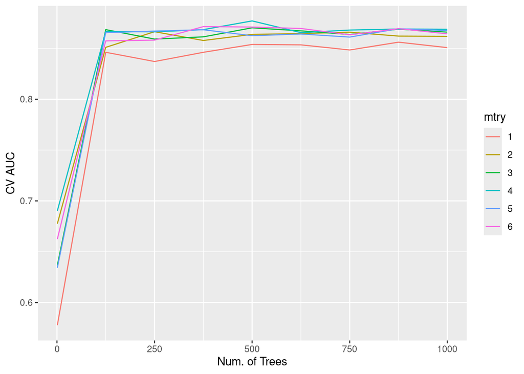

```r
rf_fit %>%
  collect_metrics() %>%
  print(width = Inf) %>%
  filter(.metric == "roc_auc") %>%
  mutate(mtry = as.factor(mtry)) %>%
  ggplot(mapping = aes(x = trees, y = mean, color = mtry)) +
  # geom_point() +
  geom_line() +
  labs(x = "Num. of Trees", y = "CV AUC")
```

```r
rf_fit %>%
  show_best("roc_auc")
```

```
# A tibble: 5 × 8
   mtry trees .metric .estimator  mean     n std_err .config
  <int> <int> <chr>   <chr>      <dbl> <int>   <dbl> <chr>
1     4   500 roc_auc binary     0.877     5  0.0150 Preprocessor1_Model32
2     6   375 roc_auc binary     0.872     5  0.0179 Preprocessor1_Model49
3     6   500 roc_auc binary     0.871     5  0.0200 Preprocessor1_Model50
4     3   500 roc_auc binary     0.870     5  0.0131 Preprocessor1_Model23
5     6   625 roc_auc binary     0.870     5  0.0177 Preprocessor1_Model51
```

```r
best_rf <- rf_fit %>%
  select_best("roc_auc")
best_rf
```

```
# A tibble: 1 × 3
   mtry trees .config
  <int> <int> <chr>
1     4   500 Preprocessor1_Model32
```

```r
# Final workflow
final_wf <- rf_wf %>%
  finalize_workflow(best_rf)
final_wf
```

```
══ Workflow ════════════════════════════════════════════════════════════════════
Preprocessor: Recipe
Model: rand_forest()

── Preprocessor ────────────────────────────────────────────────────────────────
1 Recipe Step

• step_zv()

── Model ───────────────────────────────────────────────────────────────────────
Random Forest Model Specification (classification)

Main Arguments:
  mtry = 4
  trees = 500

Computational engine: ranger
```

```r
# Fit the whole training set, then predict the test cases
final_fit <-
  final_wf %>%
  last_fit(data_split)
final_fit
```

```
# Resampling results
# Manual resampling
# A tibble: 1 × 6
  splits            id               .metrics .notes   .predictions .workflow
  <list>            <chr>            <list>   <list>   <list>       <list>
1 <split [300/100]> train/test split <tibble> <tibble> <tibble>     <workflow>
```

```r
# Test metrics
final_fit %>%
  collect_metrics()
```

```
# A tibble: 2 × 4
  .metric  .estimator .estimate .config
  <chr>    <chr>          <dbl> <chr>
1 accuracy binary         0.81  Preprocessor1_Model1
2 roc_auc  binary         0.880 Preprocessor1_Model1
```

**Answer:** The best training roc_auc is at 0.877 while the test roc_auc is at 0.880. There is a slight improvement in the prediction of the test set. There is no overfitting because my test score performed better than the training score. A score of 0.880 suggests that the model has a high degree of discriminatory power, meaning it can effectively differentiate between the High Sales and Low Sales categories based on the predictors included in the Carseats.

### 5.2 boosting for classification

```r
# Load libraries
library(GGally)
library(gtsummary)
library(ranger)
library(tidyverse)
library(tidymodels)
library(xgboost)
library(ISLR2)

# checking for missing values
summary(Carseats)
```

```
     Sales          CompPrice       Income        Advertising
 Min.   : 0.000   Min.   : 77   Min.   : 21.00   Min.   : 0.000
 1st Qu.: 5.390   1st Qu.:115   1st Qu.: 42.75   1st Qu.: 0.000
 Median : 7.490   Median :125   Median : 69.00   Median : 5.000
 Mean   : 7.496   Mean   :125   Mean   : 68.66   Mean   : 6.635
 3rd Qu.: 9.320   3rd Qu.:135   3rd Qu.: 91.00   3rd Qu.:12.000
 Max.   :16.270   Max.   :175   Max.   :120.00   Max.   :29.000
   Population        Price        ShelveLoc        Age          Education
 Min.   : 10.0   Min.   : 24.0   Bad   : 96   Min.   :25.00   Min.   :10.0
 1st Qu.:139.0   1st Qu.:100.0   Good  : 85   1st Qu.:39.75   1st Qu.:12.0
 Median :272.0   Median :117.0   Medium:219   Median :54.50   Median :14.0
 Mean   :264.8   Mean   :115.8                Mean   :53.32   Mean   :13.9
 3rd Qu.:398.5   3rd Qu.:131.0                3rd Qu.:66.00   3rd Qu.:16.0
 Max.   :509.0   Max.   :191.0                Max.   :80.00   Max.   :18.0
 Urban       US
 No :118   No :142
 Yes:282   Yes:258
```

```r
colSums(is.na(Carseats))
```

```
      Sales   CompPrice      Income Advertising  Population       Price
          0           0           0           0           0           0
  ShelveLoc         Age   Education       Urban          US
          0           0           0           0           0
```

```r
Carseats %>% tbl_summary()
```

| **Characteristic** | **N = 400**<sup>1</sup> |
| --- | --- |
| Sales | 7.49 (5.39, 9.32) |
| CompPrice | 125 (115, 135) |
| Income | 69 (43, 91) |
| Advertising | 5.0 (0.0, 12.0) |
| Population | 272 (139, 399) |
| Price | 117 (100, 131) |
| ShelveLoc |  |
| Bad | 96 (24%) |
| Good | 85 (21%) |
| Medium | 219 (55%) |
| Age | 55 (40, 66) |
| Education |  |
| 10 | 48 (12%) |
| 11 | 48 (12%) |
| 12 | 49 (12%) |
| 13 | 43 (11%) |
| 14 | 40 (10%) |
| 15 | 36 (9.0%) |
| 16 | 47 (12%) |
| 17 | 49 (12%) |
| 18 | 40 (10%) |
| Urban | 282 (71%) |
| US | 258 (65%) |

<sup>1</sup> Median (IQR); n (%)

```r
# For reproducibility
set.seed(212)

# creating an outcome variable
carseats <- Carseats %>%
  mutate(SalesHL = ifelse(Sales <= 8, "Low", "High")) %>%
  select(-Sales)

data_split <- initial_split(
  carseats,
  # stratify by AHD
  strata = "SalesHL",
  prop = 0.75
  )
data_split
```

```
<Training/Testing/Total>
<300/100/400>
```

```r
carseats_train <- training(data_split)
dim(carseats_train)
```

```
[1] 300  11
```

```r
carseats_test <- testing(data_split)
dim(carseats_test)
```

```
[1] 100  11
```

```r
gb_recipe <-
  recipe(
    SalesHL ~ .,
    data = carseats_train
  ) %>%
  # create traditional dummy variables (necessary for xgboost)
  step_dummy(all_nominal_predictors()) %>%
  # zero-variance filter
  step_zv(all_numeric_predictors())
  # estimate the means and standard deviations
  # prep(training = carseats_train, retain = TRUE)
gb_recipe

gb_mod <-
  boost_tree(
    mode = "classification",
    trees = 1000,
    tree_depth = tune(),
    learn_rate = tune()
  ) %>%
  set_engine("xgboost")
gb_mod
```

```
Boosted Tree Model Specification (classification)

Main Arguments:
  trees = 1000
  tree_depth = tune()
  learn_rate = tune()

Computational engine: xgboost
```

```r
gb_wf <- workflow() %>%
  add_recipe(gb_recipe) %>%
  add_model(gb_mod)
gb_wf
```

```
══ Workflow ════════════════════════════════════════════════════════════════════
Preprocessor: Recipe
Model: boost_tree()

── Preprocessor ────────────────────────────────────────────────────────────────
2 Recipe Steps

• step_dummy()
• step_zv()

── Model ───────────────────────────────────────────────────────────────────────
Boosted Tree Model Specification (classification)

Main Arguments:
  trees = 1000
  tree_depth = tune()
  learn_rate = tune()

Computational engine: xgboost
```

```r
param_grid <- grid_regular(
  tree_depth(range = c(1L, 5L)),
  learn_rate(range = c(-3, 4), trans = log10_trans()),
  levels = c(5, 7)
  )
param_grid
```

```
# A tibble: 35 × 2
   tree_depth learn_rate
        <int>      <dbl>
 1          1     0.001
 2          2     0.001
 3          3     0.001
 4          4     0.001
 5          5     0.001
 6          1     0.0147
 7          2     0.0147
 8          3     0.0147
 9          4     0.0147
10          5     0.0147
# ℹ 25 more rows
```

```r
set.seed(203)

folds <- vfold_cv(carseats_train, v = 5)
folds
```

```
#  5-fold cross-validation
# A tibble: 5 × 2
  splits           id
  <list>           <chr>
1 <split [240/60]> Fold1
2 <split [240/60]> Fold2
3 <split [240/60]> Fold3
4 <split [240/60]> Fold4
5 <split [240/60]> Fold5
```

```r
gb_fit <- gb_wf %>%
  tune_grid(
    resamples = folds,
    grid = param_grid,
    metrics = metric_set(roc_auc, accuracy)
    )
gb_fit
```

```
# Tuning results
# 5-fold cross-validation
# A tibble: 5 × 4
  splits           id    .metrics          .notes
  <list>           <chr> <list>            <list>
1 <split [240/60]> Fold1 <tibble [70 × 6]> <tibble [0 × 3]>
2 <split [240/60]> Fold2 <tibble [70 × 6]> <tibble [0 × 3]>
3 <split [240/60]> Fold3 <tibble [70 × 6]> <tibble [0 × 3]>
4 <split [240/60]> Fold4 <tibble [70 × 6]> <tibble [0 × 3]>
5 <split [240/60]> Fold5 <tibble [70 × 6]> <tibble [0 × 3]>
```

```
# A tibble: 70 × 8
   tree_depth learn_rate .metric  .estimator  mean     n std_err
        <int>      <dbl> <chr>    <chr>      <dbl> <int>   <dbl>
 1          1      0.001 accuracy binary     0.71      5  0.0227
 2          1      0.001 roc_auc  binary     0.781     5  0.0304
 3          2      0.001 accuracy binary     0.75      5  0.0346
 4          2      0.001 roc_auc  binary     0.811     5  0.0381
 5          3      0.001 accuracy binary     0.777     5  0.0360
 6          3      0.001 roc_auc  binary     0.844     5  0.0386
 7          4      0.001 accuracy binary     0.773     5  0.0310
 8          4      0.001 roc_auc  binary     0.856     5  0.0278
 9          5      0.001 accuracy binary     0.78      5  0.0406
10          5      0.001 roc_auc  binary     0.859     5  0.0241
   .config
   <chr>
 1 Preprocessor1_Model01
 2 Preprocessor1_Model01
 3 Preprocessor1_Model02
 4 Preprocessor1_Model02
 5 Preprocessor1_Model03
 6 Preprocessor1_Model03
 7 Preprocessor1_Model04
 8 Preprocessor1_Model04
 9 Preprocessor1_Model05
10 Preprocessor1_Model05
# ℹ 60 more rows
```

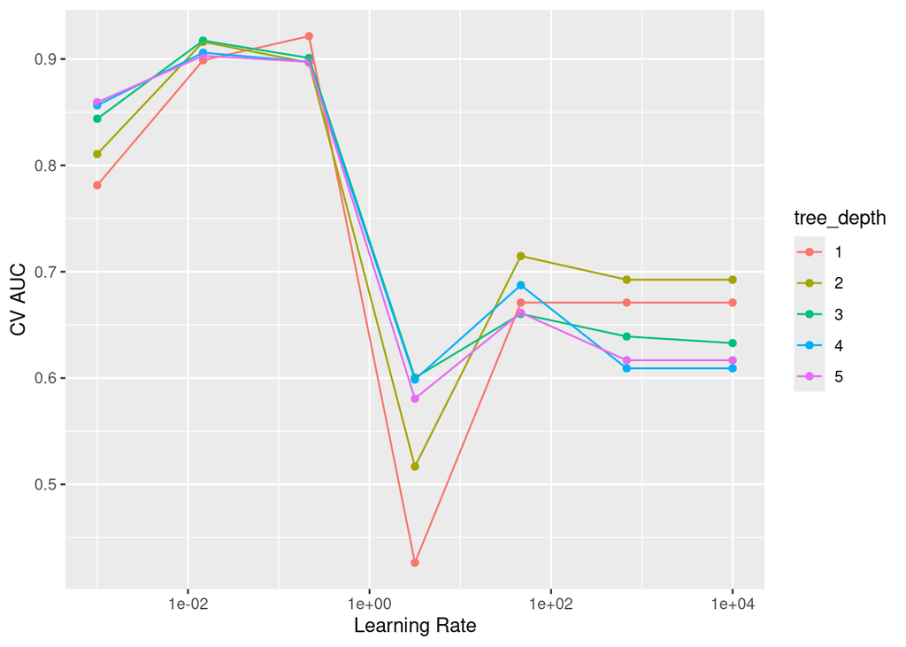

```r
gb_fit %>%
  collect_metrics() %>%
  print(width = Inf) %>%
  filter(.metric == "roc_auc") %>%
  mutate(tree_depth = as.factor(tree_depth)) %>%
  ggplot(mapping = aes(x = learn_rate, y = mean, color = tree_depth)) +
  geom_point() +
  geom_line() +
  labs(x = "Learning Rate", y = "CV AUC") +
  scale_x_log10()
```

```r
gb_fit %>%
  show_best("roc_auc")
```

```
# A tibble: 5 × 8
  tree_depth learn_rate .metric .estimator  mean     n std_err .config
       <int>      <dbl> <chr>   <chr>      <dbl> <int>   <dbl> <chr>
1          1     0.215  roc_auc binary     0.921     5  0.0149 Preprocessor1_Mo…
2          3     0.0147 roc_auc binary     0.917     5  0.0163 Preprocessor1_Mo…
3          2     0.0147 roc_auc binary     0.916     5  0.0169 Preprocessor1_Mo…
4          4     0.0147 roc_auc binary     0.906     5  0.0185 Preprocessor1_Mo…
5          5     0.0147 roc_auc binary     0.903     5  0.0178 Preprocessor1_Mo…
```

```r
best_gb <- gb_fit %>%
  select_best("roc_auc")
best_gb
```

```
# A tibble: 1 × 3
  tree_depth learn_rate .config
       <int>      <dbl> <chr>
1          1      0.215 Preprocessor1_Model11
```

```r
# Final workflow
final_wf <- gb_wf %>%
  finalize_workflow(best_gb)
final_wf
```

```
══ Workflow ════════════════════════════════════════════════════════════════════
Preprocessor: Recipe
Model: boost_tree()

── Preprocessor ────────────────────────────────────────────────────────────────
2 Recipe Steps

• step_dummy()
• step_zv()

── Model ───────────────────────────────────────────────────────────────────────
Boosted Tree Model Specification (classification)

Main Arguments:
  trees = 1000
  tree_depth = 1
  learn_rate = 0.215443469003188

Computational engine: xgboost
```

```r
# Fit the whole training set, then predict the test cases
final_fit <-
  final_wf %>%
  last_fit(data_split)
final_fit
```

```
# Resampling results
# Manual resampling
# A tibble: 1 × 6
  splits            id               .metrics .notes   .predictions .workflow
  <list>            <chr>            <list>   <list>   <list>       <list>
1 <split [300/100]> train/test split <tibble> <tibble> <tibble>     <workflow>
```

```r
# Test metrics
final_fit %>%
  collect_metrics()
```

```
# A tibble: 2 × 4
  .metric  .estimator .estimate .config
  <chr>    <chr>          <dbl> <chr>
1 accuracy binary         0.79  Preprocessor1_Model1
2 roc_auc  binary         0.895 Preprocessor1_Model1
```

**Answer:** The best training roc_auc is at 0.921 while the test roc_auc is at 0.895. The slight decrease in roc_auc suggests that there might be a small amount of overfitting. However, the gap is not large, indicating that any overfitting is likely minimal. A score of 0.895 suggests that the model has a high degree of discriminatory power, meaning it can effectively differentiate between the High Sales and Low Sales categories based on the predictors included in the Carseats. Although there is risk of overfitting but the boosting tree method has a better test performance with a higher roc_auc estimate.